# Heron O. Hilário

Data de Publicação

26 de outubro de 2026

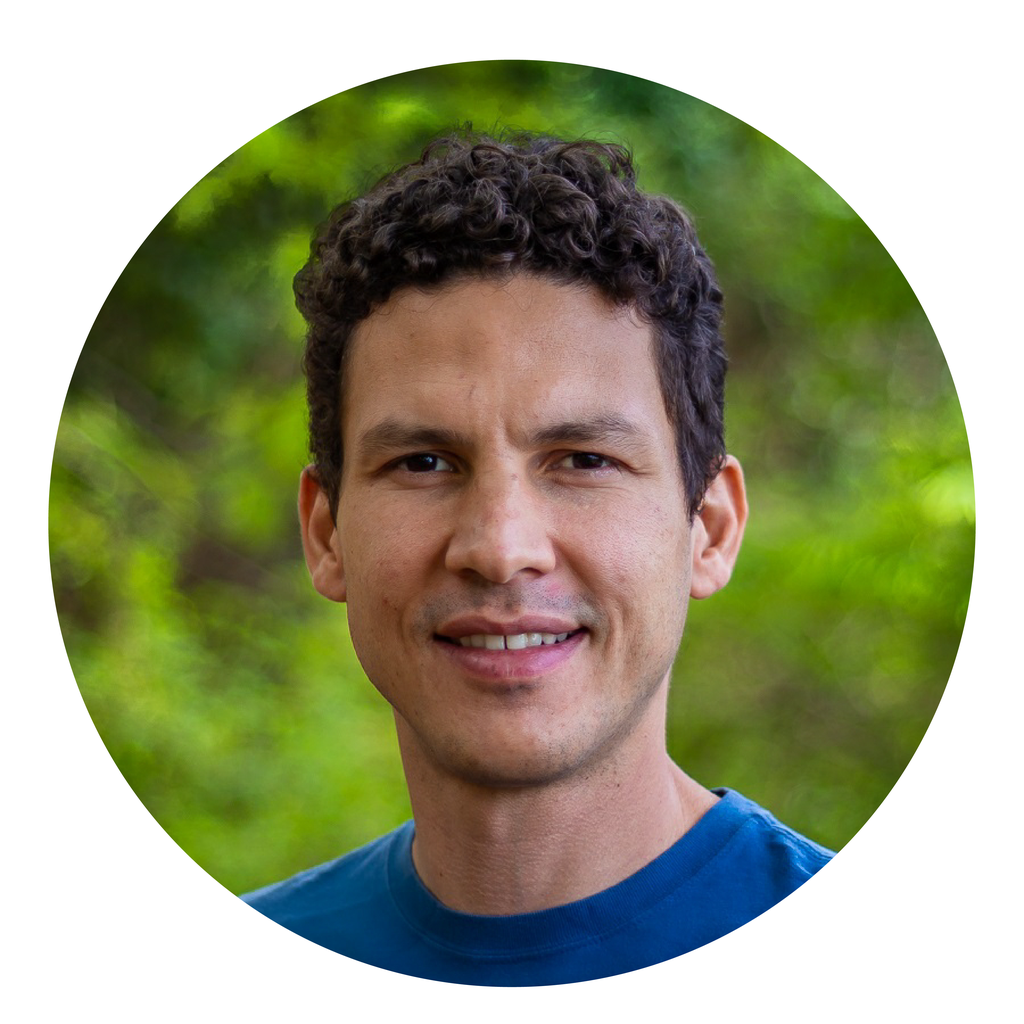

[🐙 GitHub](https://github.com/heronoh) [📚 Google Scholar](https://scholar.google.com/citations?user=e0PUfXoAAAAJ&hl=en&oi=ao) [🧬 ORCID](https://orcid.org/0000-0002-2548-1053) [📄 Lattes](http://lattes.cnpq.br/3654105041586325) [📷 Instagram](http://instagram.com/hohphoto)

## Quem sou

Sou bioinformata e trabalho com o estudo e a conservação da **biodiversidade** usando ferramentas de **biologia molecular**, **genética** e **genômica**. Minha principal linha de pesquisa é o uso de *metabarcoding* de DNA ambiental (eDNA) para inventariar e monitorar vertebrados e invertebrados.

## O que faço

- **Docência:** *Bioinformática e Genômica*, *Genética* e *Biologia Molecular* na PUC Minas.
- **Pesquisa:** pesquisador do [Laboratório de Genética da Conservação (LGC) da PUC Minas](https://www.instagram.com/lgc_pucminas/), com análise de dados ômicos (FASTA/FASTQ), filogenia e taxonomia molecular.
- **Software:** desenvolvo o pacote R [BLASTr](https://heronoh.github.io/BLASTr/), para identificação taxonômica de sequências de *metabarcoding*.
- **Consultoria:** bioinformata parceiro da [EcoMol Consultoria](https://ecomolconsultoria.com.br/), onde faço as análises de dados de eDNA *metabarcoding*.
- **Ferramentas:** R, Quarto, git/GitHub, Linux/shell.

> **Missão:** tornar os métodos computacionais em biologia mais acessíveis, com materiais claros, reproduzíveis e abertos.

## About me

I am a bioinformatician working on the study and conservation of **biodiversity** with tools from **molecular biology**, **genetics** and **genomics**. My main research line is **environmental DNA (eDNA) *metabarcoding*** for surveying and monitoring vertebrates and invertebrates.

## What I do

- **Teaching:** *Bioinformatics and Genomics*, *Genetics* and *Molecular Biology* at PUC Minas (Brazil).
- **Research:** researcher at the [Conservation Genetics Laboratory (LGC), PUC Minas](https://www.instagram.com/lgc_pucminas/), working with omics data (FASTA/FASTQ), phylogenetics and molecular taxonomy.
- **Software:** developer of the R package [BLASTr](https://heronoh.github.io/BLASTr/), for taxonomic identification of *metabarcoding* sequences.
- **Consulting:** partner bioinformatician at [EcoMol Consultoria](https://ecomolconsultoria.com.br/), responsible for eDNA *metabarcoding* data analysis.
- **Tools:** R, Quarto, git/GitHub, Linux/shell.

> **Mission:** making computational methods in biology more accessible through clear, reproducible and open materials.

[figure not shown]

[figure not shown]